# Statistical inference with the GSS data

## Setup

### Load packages

```r
library(ggplot2)
library(dplyr)
library(statsr)
```

### Load data

Make sure your data and R Markdown files are in the same directory. When loaded your data file will be called `gss`. Delete this note when before you submit your work.

```r
load("gss.Rdata")
```

## Part 1: Data

About the Data: The GSS aims to gather data on contemporary American society in order to monitor and explain trends and constants in attitudes, behaviors, and attributes. to compare the United States to other societies in order to place American society in comparative perspective and develop cross-national models of human society; and to make high-quality data easily accessible to scholars, students, policy makers.(Sources: http://www.norc.org/Research/Projects/Pages/general-social-survey.aspx)

This is **not a randomized experiment**, hence it **cannot be generalized for the total population**, but **association can be drawn** from the given data

A glimpse into the different parameters of the data :-

```r
names(gss)
```

```
##   [1] "caseid"   "year"     "age"      "sex"      "race"     "hispanic"
##   [7] "uscitzn"  "educ"     "paeduc"   "maeduc"   "speduc"   "degree"
##  [13] "vetyears" "sei"      "wrkstat"  "wrkslf"   "marital"  "spwrksta"
##  [19] "sibs"     "childs"   "agekdbrn" "incom16"  "born"     "parborn"
##  [25] "granborn" "income06" "coninc"   "region"   "partyid"  "polviews"
##  [31] "relig"    "attend"   "natspac"  "natenvir" "natheal"  "natcity"
##  [37] "natcrime" "natdrug"  "nateduc"  "natrace"  "natarms"  "nataid"
##  [43] "natfare"  "natroad"  "natsoc"   "natmass"  "natpark"  "confinan"
##  [49] "conbus"   "conclerg" "coneduc"  "confed"   "conlabor" "conpress"
##  [55] "conmedic" "contv"    "conjudge" "consci"   "conlegis" "conarmy"
##  [61] "joblose"  "jobfind"  "satjob"   "richwork" "jobinc"   "jobsec"
##  [67] "jobhour"  "jobpromo" "jobmeans" "class"    "rank"     "satfin"
##  [73] "finalter" "finrela"  "unemp"    "govaid"   "getaid"   "union"
##  [79] "getahead" "parsol"   "kidssol"  "abdefect" "abnomore" "abhlth"
##  [85] "abpoor"   "abrape"   "absingle" "abany"    "pillok"   "sexeduc"
##  [91] "divlaw"   "premarsx" "teensex"  "xmarsex"  "homosex"  "suicide1"
##  [97] "suicide2" "suicide3" "suicide4" "fear"     "owngun"   "pistol"
## [103] "shotgun"  "rifle"    "news"     "tvhours"  "racdif1"  "racdif2"
## [109] "racdif3"  "racdif4"  "helppoor" "helpnot"  "helpsick" "helpblk"
```

## Part 2: Research question

A question which have been very frequently discussed, is the possession of arms policy in the United States, this motivated me to carry this analysis Also, there is data available whether people hold arms or not. My research question goes into the lines **whether there is a significant difference** in the **different races** (the **proportion of the population**) Specifically for the whites and the blacks.

Idea: A lot of times differences among different races is extensively discussed, owning guns is one unique approach to it

## Part 3: Exploratory data analysis

For the purpose of analysis first the data is studied for the differenct races, a new vaiable abc is formed, which holds the count of the people in the United States grouped by their race.

```r
abc <- gss %>%
  group_by(race) %>%
  summarise(rcount = n())
```

The abc variable :-

```r
abc
```

```
## # A tibble: 3 x 2
##     race rcount
##   <fctr>  <int>
## 1  White  46350
## 2  Black   7926
## 3  Other   2785
```

Note : The rcount holds the count of the people grouped by their race

Let’s have a look at the graph to get a better insight of the population :-

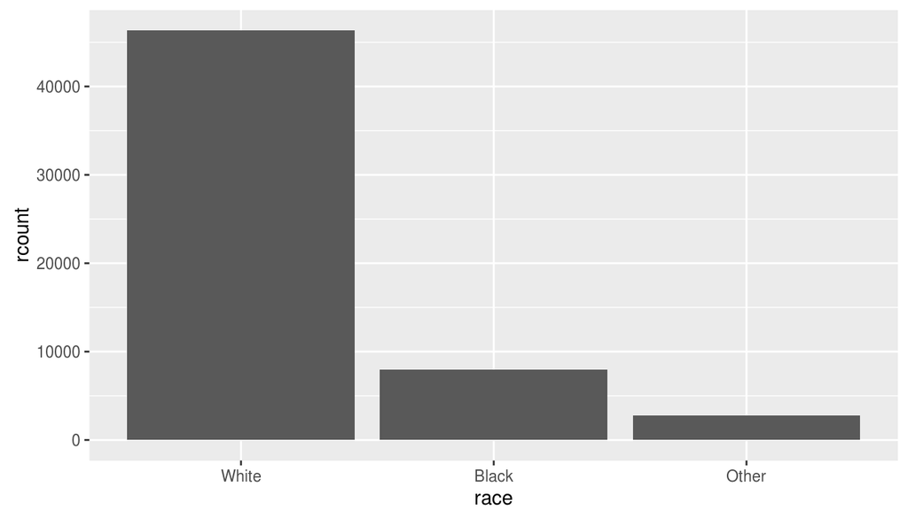

```r
ggplot(data = abc, aes(x=race,y=rcount)) + geom_bar(stat = "identity")
```

This is **particularly expected as there is a larger white population**, hence it will be **better if carry our analysis in the proportions**, in comparison to the total population

Next, we make a variable race_owngun which has the the count of the people grouped by their races and the condition that they own a gun

```r
race_owngun <- gss %>%
  group_by(race) %>%
  filter(owngun=="Yes") %>%
  summarise(count = n())
```

the race_owngun variable :

```r
race_owngun
```

```
## # A tibble: 3 x 2
##     race count
##   <fctr> <int>
## 1  White 12448
## 2  Black  1269
## 3  Other   283
```

Graphical view of the observations :

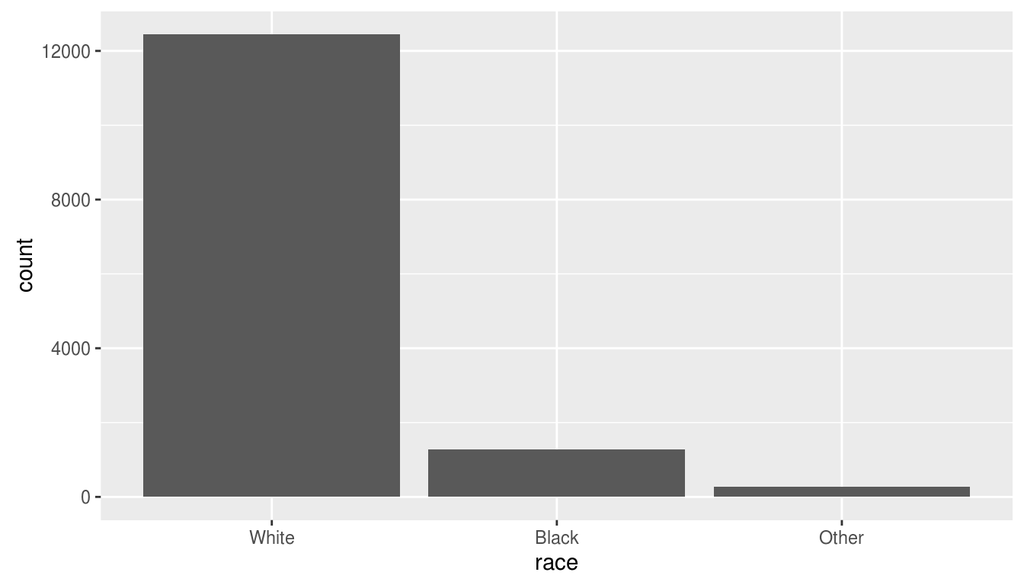

```r
ggplot(data = race_owngun, aes(x=race,y=count)) + geom_bar(stat = "identity")
```

again, the problem of persists, hence it is better to look at the proportions

Mutating race_owngun, to include the rcount

```r
race_owngun <- race_owngun %>%
  mutate(rcount = abc$rcount)
```

Now race_owngun looks like :-

```r
race_owngun
```

```
## # A tibble: 3 x 3
##     race count rcount
##   <fctr> <int>  <int>
## 1  White 12448  46350
## 2  Black  1269   7926
## 3  Other   283   2785
```

Now calculating the percentages/proportions :

```r
race_owngun <- race_owngun %>%
  mutate(prop = count/rcount)
```

Now race_owngun looks like :-

```r
race_owngun
```

```
## # A tibble: 3 x 4
##     race count rcount      prop
##   <fctr> <int>  <int>     <dbl>
## 1  White 12448  46350 0.2685653
## 2  Black  1269   7926 0.1601060
## 3  Other   283   2785 0.1016158
```

Now, let’s have a look at the graphical representation

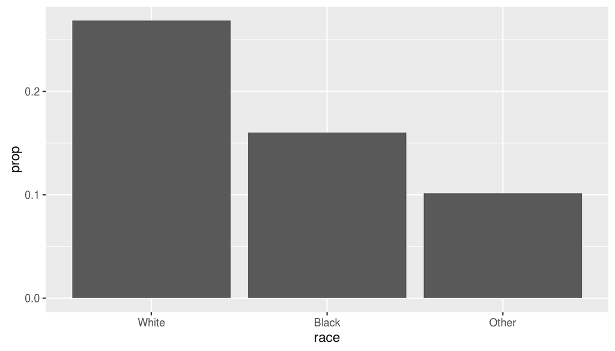

```r
ggplot(data = race_owngun,aes(race,prop)) + geom_bar(stat = "identity")
```

again from this what seems, is that evident that **guns are owned more by the white population in comparison to the black and the other population**

Though again **nothing concrete can be said**.

## Part 4: Inference

Hence, for a concrete statement on the question posed we need to perform **Inference on the collected data** Let us consider the proportions of the white and black that hold a gun

The Inference technique that will be applied is the **Sample distribution of the difference of two proportions**

let **p1 be the sample proportion for the Whites** let **p2 be the sample proportion for the Blacks**

first we will have to check for the condition to of the inference

**1.Independence :-** it can be safely be assumed that the White and the Black population are **less than 10% of the total population of Whites and Blacks in the United States of America** hence it **can be assumed to be independent.**

**2.Success Faliure Condtiion :-** This has to be calculate for both p1 and p2

n1p1 = 12448>10 n1(1-p1) = 33902>10

n2p2 = 1269>10 n2(1-p2) = 6657>10

Hence **this condition also holds**

**Using Hypothesis Testing :**

**Hypothesise :-**

**Ho : There is no difference in the proportion of the White and Black population owning a gun.** **Ha : There is a difference in the proportion of the White and Black population owning a gun.**

Let P1 and P2 be the population proportions

In a hypothesis test involving the Hypothesis P1=P2, **Pooled proportions are used**

Let Pp be the pooled proportion. Pp = (12448+1269)/(46350+7926)= 0.2527268

Hence the Standard Error is
$$\sqrt{ \frac{Pp(1-Pp)}{n1} + \frac{Pp(1-Pp)}{n2} }$$

SE = 0.005282231

hence the Z score would be

Z = (0.2685653-0.1601060)/0.005282231 = 20.53286

Hence now carrying out the inference

hence the pvalue is calculated as

```r
pnorm(20.53286,lower.tail = FALSE)*2
```

```
## [1] 1.095343e-93
```

which is very very small hence the hypothesis is rejected at 5% significance level

that is our P-value is less than the significance level 0.05, hecne we reject the hypothesis and state that there is a difference between the proportion of the whites and Blacks that own a gun

**Using Confidence Interval :**

Pooled Proportions is not required in the CI calculations for comparing two proportions

The Standard Error will be calculated using :

$$\sqrt{ \frac{p1(1-p1)}{n1} + \frac{p2(1-p2)}{n2} }$$

Hence the Standard Error is : SD = 0.00460479

The confidence interval is created using the formulae : (p1-p2) +/- z*SE

for 95% confidence level **z = 1.96**

**There is a significant differnece and is in agreement with the Hypothesis Test**

**According to our data there is a difference in the proportions of the White and Black population those who own a gun**